# Лабораторная работа № 8

Планировщики событий

Павличенко Родион Андреевич

1132246838@pfur.ru

Российский университет дружбы народов

# Информация

## Докладчик

- Павличенко Родион Андреевич
- Cтудент
- Группа НПИбд-02-24
- Российский университет дружбы народов им. П. Лумумбы
- 1132246838@pfur.ru

# Выполнение лабораторной работы

## Запустили терминал и получили полномочия администратора. Посмотрели статус демона crond. Посмотрели содержимое файла конфигурации /etc/crontab

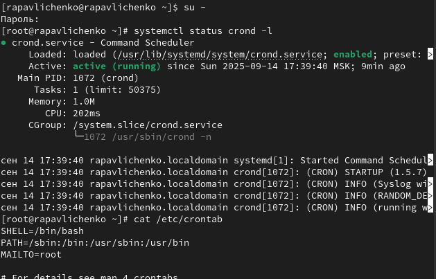

Рисунок 1: Просмотр статуса crond

## Посмотрели список заданий в расписании. Ничего не отобразилось, так как расписание ещё не было задано. Открыли файл расписания на редактирование. Добавили следующую строку в файл расписания (запись сообщения в системный журнал), используя Ins для перехода в vi в режим ввода: */1* * * * logger This message is written from root cron

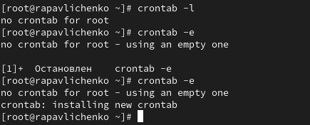

Рисунок 2: Добавление задания

## Посмотрели список заданий в расписании. В расписании появилась запись о запланированном событии. Не выключая систему, через некоторое время (2–3 минуты) просмотрели журнал системных событий. Заметили, что раз в минуту приходило сообщение

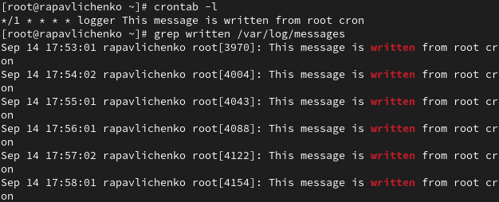

Рисунок 3: Запись о событии

## Изменили запись в расписании crontab на следующую: 0 */1* * 1-5 logger This message is written from root cron. Посмотрели список заданий в расписании. Перешли в каталог /etc/cron.hourly и создали в нём файл сценария с именем eachhour

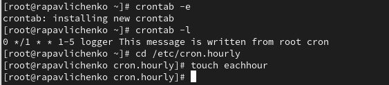

Рисунок 4: Изменение записи в расписании crontab

## Открыли файл eachhour для редактирования и прописали в нём следующий скрипт

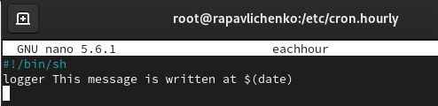

Рисунок 5: Работа с файлом eachhour

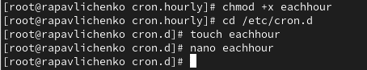

Рисунок 6: Работа с файлом eachhour

## Сохранили изменения. Не выключая систему, через некоторое время просмотрели журнал системных событий

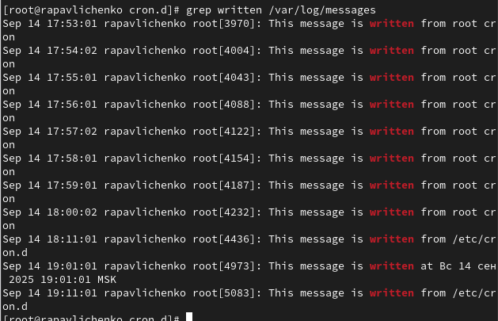

Рисунок 7: Просмотр журнала изменений

## Запустили терминал и получили полномочия администратора. Проверили, что служба atd загружена и включена. Задали выполнение команды logger message from at в 19:18 . Убедились, что задание действительно запланировано

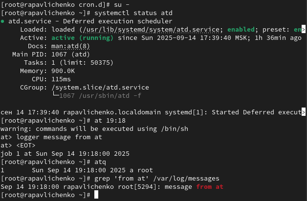

Рисунок 8: Работа с atd